# General Social Survey

Jeffrey Roderick

10-07-19

# 1 Introduction Question 1

This data is from the 2018 General Social Survey. The first blocks of R-code has selected down a subset of the data to just 15 variables. It has further removed unwanted factor levels in much of the data. Examine that code to see what it is doing. Finally address this question. Is opinion on the death penalty (CAPPUN) independent of gun ownership (OWNGUN)?

## 1.1 Methods

Both variable in this analysis are categorical; hence we use bar graphs and tables to summarizes the data, and a chi-squared test for inference.

$H_0$ : There is no relationship bewteen gun ownership and whether one is in favor of captial punishment.

$H_A$ : There is a relationship bewteen gun ownership and captial punishment.

## 1.2 Results

### 1.2.1 Descriptive Results

#### 1.2.1.1 Graphical Descriptive Results

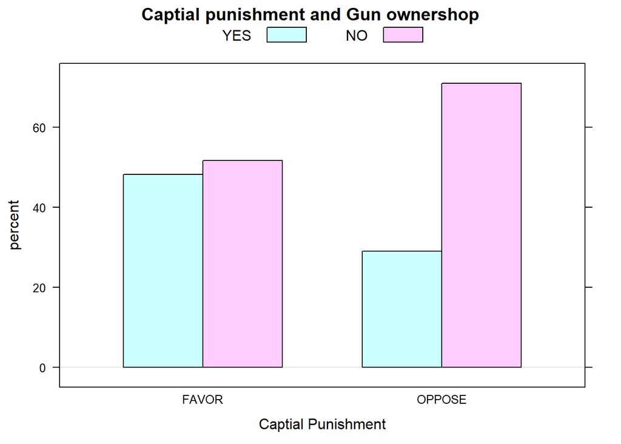

```r
barchartGC(~CAPPUN+OWNGUN, data=mydata4, main='Captial punishment and Gun ownershop', type='percent', xlab= 'Captial Punishment')
```

This barcharts shows that people who favor captial punishment are more likely to own a firearm. In addition people who do not own a gun are more likely to oppose captial punishment.

#### 1.2.1.2 Numerical Descriptive Results

```r
table1= xtabs(~CAPPUN+OWNGUN, data=mydata4)
rowPerc(table1)
```

```
##         OWNGUN
## CAPPUN      YES     NO  Total
##   FAVOR   48.28  51.72 100.00
##   OPPOSE  29.03  70.97 100.00
```

This table displays if person who owns a gun are more likely to favor captial punishment, oppose to the ones who do not own a gun with numerical values.

### 1.2.2 Inferential Results

```r
chisqtestGC(table1)
```

```
## Pearson's Chi-squared test with Yates' continuity correction
##
## Observed Counts:
##         OWNGUN
## CAPPUN   YES NO
##   FAVOR   56 60
##   OPPOSE  18 44
##
## Counts Expected by Null:
##         OWNGUN
## CAPPUN     YES    NO
##   FAVOR  48.22 67.78
##   OPPOSE 25.78 36.22
##
## Contributions to the chi-square statistic:
##         OWNGUN
## CAPPUN    YES   NO
##   FAVOR  1.25 0.89
##   OPPOSE 2.35 1.67
##
##
## Chi-Square Statistic = 5.3932
## Degrees of Freedom of the table = 1
## P-Value = 0.0202
```

The p-value for the chisq test is .02 < .05, so we reject the null hypothesis and conclude we have evidence to support the contention that gun ownership and whether it favors captial punishmet are related.

# 2 Introduction Question 2

Now answer Is belief in the bigbang theory (BIGBANG) independent of belief in the afterlife (POSTLIFE)

## 2.1 Methods

$H_0$ : There is no relationship bewteen big bang theory and whether one is in favor of postlife.

$H_A$ : There is a relationship bewteen big bang theory and postlife.

## 2.2 Results

### 2.2.1 Descriptive Results

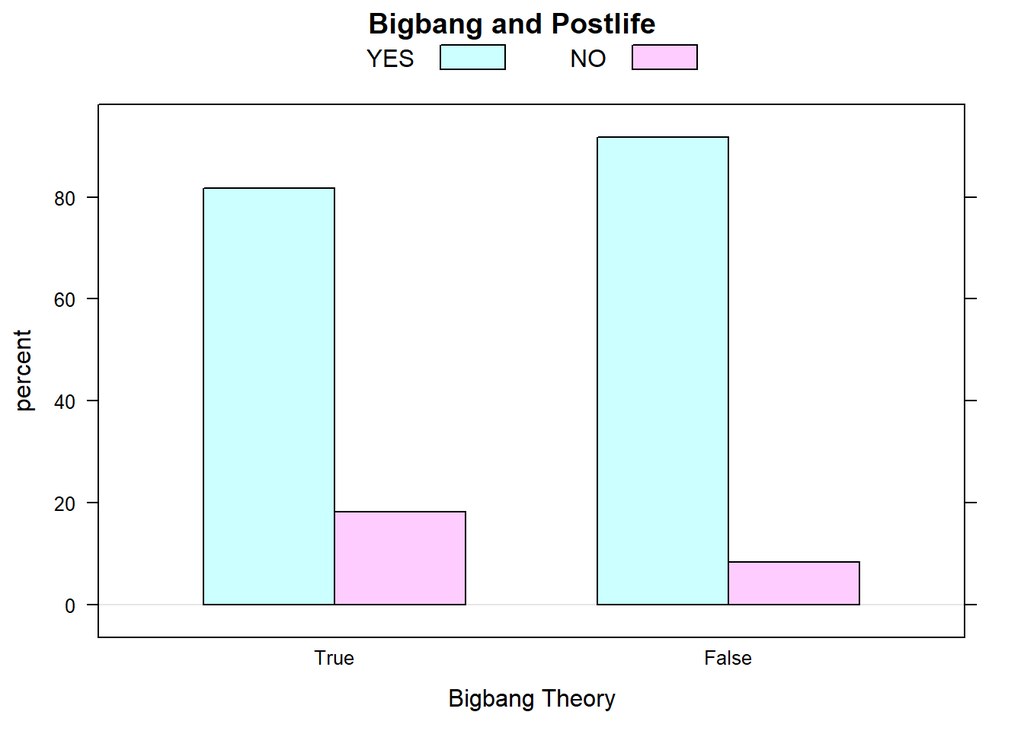

```r
barchartGC(~BIGBANG+POSTLIFE, data=mydata4, main='Bigbang and Postlife', type='percent', xlab= 'Bigbang Theory')
```

This barcharts shows that people that believe in the Bigbang theory and that do not believe in post life are unrelated.

#### 2.2.1.2 Numerical Descriptive Results

```r
table1= xtabs(~BIGBANG+POSTLIFE, data=mydata4)
rowPerc(table1)
```

```
##        POSTLIFE
## BIGBANG    YES     NO  Total
##   True   81.71  18.29 100.00
##   False  91.67   8.33 100.00
```

This table displays if person believe in the big bang theory or postlife are unrelated by numerical data provided.

### 2.2.2 Inferential Results

```r
chisqtestGC(table1)
```

```
## Pearson's Chi-squared test with Yates' continuity correction
##
## Observed Counts:
##        POSTLIFE
## BIGBANG YES NO
##   True   67 15
##   False  88  8
##
## Counts Expected by Null:
##        POSTLIFE
## BIGBANG  YES   NO
##   True  71.4 10.6
##   False 83.6 12.4
##
## Contributions to the chi-square statistic:
##        POSTLIFE
## BIGBANG  YES   NO
##   True  0.27 1.83
##   False 0.23 1.56
##
##
## Chi-Square Statistic = 3.0637
## Degrees of Freedom of the table = 1
## P-Value = 0.0801
```

The p-value for the chisq test is .0801 > .05, so we accept the null hypothesis and conclude we do not have evidence to support the contention that big bang theory and post life are related.

# 3 Introduction Question 3

Finally determine if a persons opinion on death penalty (CAPPUN) is independent of their race (RACE).

## 3.1 Methods

$H_0$ : There is no relationship bewteen captial punishment and whether one is in favor of race.

$H_A$ : There is a relationship bewteen captial punishment and race.

## 3.2 Results

### 3.2.1 Descriptive Results

#### 3.2.1.1 Graphical Descriptive Results

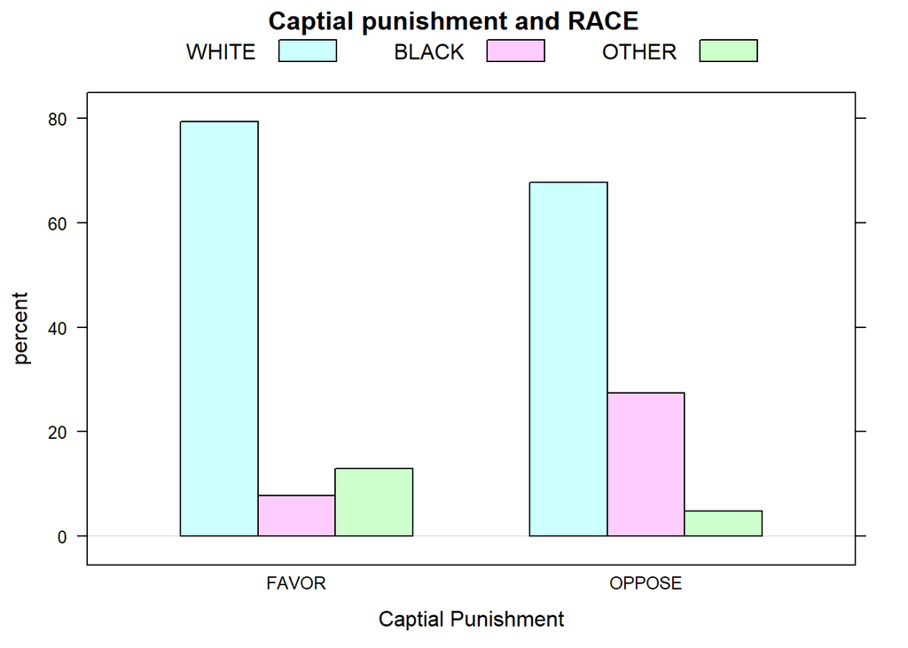

```r
barchartGC(~CAPPUN+RACE, data=mydata4, main='Captial punishment and RACE', type='percent', xlab= 'Captial Punishment')
```

#### 3.2.1.2 Numerical Descriptive Results

```r
table1= xtabs(~CAPPUN+RACE, data=mydata4)
rowPerc(table1)
```

```
##         RACE
## CAPPUN    WHITE  BLACK  OTHER  Total
##   FAVOR   79.31   7.76  12.93 100.00
##   OPPOSE  67.74  27.42   4.84 100.00
```

### 3.2.2 Inferential Results

```r
chisqtestGC(table1)
```

```
## Pearson's Chi-squared test
##
## Observed Counts:
##         RACE
## CAPPUN   WHITE BLACK OTHER
##   FAVOR     92     9    15
##   OPPOSE    42    17     3
##
## Counts Expected by Null:
##         RACE
## CAPPUN   WHITE BLACK OTHER
##   FAVOR  87.33 16.94 11.73
##   OPPOSE 46.67  9.06  6.27
##
## Contributions to the chi-square statistic:
##         RACE
## CAPPUN   WHITE BLACK OTHER
##   FAVOR   0.25  3.72  0.91
##   OPPOSE  0.47  6.97  1.71
##
##
## Chi-Square Statistic = 14.0272
## Degrees of Freedom of the table = 2
## P-Value = 9e-04
```

# 4 Discussion and Conclusion